# Cyclistic Case Study Solution with R

Göktuğ Yaman

2022-10-24

### Setting the environment

```r
library(tidyverse)
library(lubridate)
```

```r
library(ggplot2)
```

### Preparing the working directory

setwd(“/Users/goktugyaman/Documents/Data_Analysis_Case_Study/CSV”)

### Data collection: importing csv files into RStuido

all_2013 <- read_csv(“2013.csv”) q3_2014_07 <- read_csv(“2014_07.csv”) …

### Standardizing tables in order to join them into single dataframe

all_2013 <- rename(all_2013, ride_id = trip_id, rideable_type = bikeid, started_at = starttime, ended_at = stoptime, start_station_id = from_station_id, start_station_name = from_station_name, end_station_id = to_station_id, end_station_name = to_station_name, member_casual = usertype) …

### Converting data types into characters to stack them together

#### ride_id and rideable_type turned into characters

all_2013 <- mutate(all_2013, ride_id = as.character(ride_id), rideable_type = as.character(rideable_type)) …

#### Date columns turned into POSIXct, tables with problems to convert data type have been exported into excel and problem fixed

##### Setting the environment

```r
library(readxl)
```

##### Setting the working directory for excel files

setwd(“/Users/goktugyaman/Documents/Data_Analysis_Case_Study/Excels”)

##### Importing the files after csv’s splitted through terminal via split command

n_q1_q2_2014 <- read_excel(“2014_Q1Q2.xlsx”) n_q3_2014_07 <- read_excel(“2014_Q3_07.xlsx”) …

##### Adujusting column names of the excel files

n_q1_q2_2014 <- rename(n_q1_q2_2014, ride_id = trip_id, started_at = start_time, ended_at = stop_time, start_station_id = from_station_id, start_station_name = from_station_name, end_station_id = to_station_id, end_station_name = to_station_name, member_casual = user_type) …

##### Converting ride_id, end_station_id, and start_staiton_id columns into character type

n_q1_q2_2014 <- mutate(n_q1_q2_2014, ride_id = as.character(ride_id)) …

### Combining tables

all_trips <- bind_rows(all_2013, n_q1_q2_2014, n_q3_2014_07, n_q3_2014_08_09, n_q4_2014, n_q1_2015, n_q2_2015, n_q3_2015_07, n_q3_2015_08, n_q3_2015_09, n_q4_2015, …

### Standardizing member_casual column, member for subscribers and casual for casual riders

all_trips <- mutate(all_trips, member_casual = recode(member_casual, “Subscriber” = “member”, “Customer” = “casual”, “Dependent” = “casual”)) …

### Adding columns for aggregation

all_trips$date <- as.Date(all_trips$started_at) #The default format is yyyy-mm-dd all_trips$month <- format(as.Date(all_trips$date), “%m”) all_trips$day <- format(as.Date(all_trips$date), “%d”) all_trips$year <- format(as.Date(all_trips$date), “%Y”) all_trips$day_of_week <- format(as.Date(all_trips$date), “%A”)

### Adding a column for ride_length into whole table

all_trips$ride_length <- difftime(all_trips$ended_at,all_trips$started_at) all_trips$ride_length <- as.numeric(as.character(all_trips$ride_length))

### Dropping inconsistent and unrelated columns to analysis

all_trips <- all_trips %>% select(-c(“start_station_id”, “end_station_id”, “start_station_name”, “end_station_name”, “birthyear”, “gender”, “birthday”, “trip_day”, “01 - Rental Details Duration In Seconds Uncapped”, “Member Gender”, “05 - Member Details Member Birthday Year”, “start_lat”, “start_lng”, “end_lat”, “end_lng”, “tripduration”, “ride_id”, “rideable_type”))

### Removing the trips that lasted less than 120 seconds in order to eliminate test rides and untypical rides

all_trips_v2 <- all_trips[!(all_trips$ride_length<120),] all_trips_v3 <- all_trips_v2

### Fixing the ride lengths decimal difference of years 2014-2017

all_trips_v3$ride_length <- ifelse(all_trips_v3$year == 2015, all_trips_v3$ride_length/1000, all_trips_v3$ride_length) rm(all_trips_v2) …

### Fixing the ride lengths decimal difference of years 2014-2017

all_trips_v3$ride_length <- ifelse(all_trips_v3$year == 2015, all_trips_v3$ride_length/1000, all_trips_v3$ride_length) rm(all_trips_v2) all_trips_v4 <- all_trips_v3 all_trips_v4$ride_length <- ifelse(all_trips_v4$year == 2016, all_trips_v4$ride_length/1000, all_trips_v4$ride_length) rm(all_trips_v3) all_trips_v5 <- all_trips_v4 all_trips_v5$ride_length <- ifelse(all_trips_v5$year == 2017, all_trips_v5$ride_length/1000, all_trips_v5$ride_length) all_trips_v6 <- all_trips_v5 rm(all_trips_v4) all_trips_v6$ride_length <- ifelse(all_trips_v6$year == 2014, all_trips_v6$ride_length/10, all_trips_v6$ride_length) rm(all_trips_v5)

### Sorting the data according to weekday

```r
all_trips_v6$day_of_week <- ordered(all_trips_v6$day_of_week,
                                    levels=c("Monday", "Tuesday", "Wednesday", "Thursday",                                                    "Friday", "Saturday", "Sunday"))
```

### Summary statistics (values in seconds)

##### Average trip duration for both subscribers and casual riders

```r
aggregate(all_trips_v6$ride_length ~ all_trips_v6$member_casual, FUN = mean)
```

```
##   all_trips_v6$member_casual all_trips_v6$ride_length
## 1                     casual                 2076.476
## 2                     member                 1065.401
```

##### Median value of trip duration for both customer groups

```r
aggregate(all_trips_v6$ride_length ~ all_trips_v6$member_casual, FUN = median)
```

```
##   all_trips_v6$member_casual all_trips_v6$ride_length
## 1                     casual                      771
## 2                     member                      330
```

##### Maximum trip duration for both customer groups

```r
aggregate(all_trips_v6$ride_length ~ all_trips_v6$member_casual, FUN = max)
```

```
##   all_trips_v6$member_casual all_trips_v6$ride_length
## 1                     casual                 14340041
## 2                     member                 13561217
```

##### Minimum trip duration for both customer groups

```r
aggregate(all_trips_v6$ride_length ~ all_trips_v6$member_casual, FUN = min)
```

```
##   all_trips_v6$member_casual all_trips_v6$ride_length
## 1                     casual                     0.12
## 2                     member                     0.12
```

##### Average trip duration for both customer groups, grouped by weekdays

```r
aggregate(all_trips_v6$ride_length ~ all_trips_v6$member_casual + all_trips_v6$day_of_week, FUN = mean)
```

```
##    all_trips_v6$member_casual all_trips_v6$day_of_week all_trips_v6$ride_length
## 1                      casual                   Monday                1929.8375
## 2                      member                   Monday                1035.4225
## 3                      casual                  Tuesday                1979.0099
## 4                      member                  Tuesday                1019.2519
## 5                      casual                Wednesday                1995.8832
## 6                      member                Wednesday                 999.9072
## 7                      casual                 Thursday                2063.1012
## 8                      member                 Thursday                1081.9488
## 9                      casual                   Friday                2116.8457
## 10                     member                   Friday                1088.6521
## 11                     casual                 Saturday                2091.3233
## 12                     member                 Saturday                1132.0400
## 13                     casual                   Sunday                2203.9699
## 14                     member                   Sunday                1154.6074
```

### Analysis on total number of rides

#### Daily

The daily number of different customer groups shows that the number of members is always higher than the casual riders. The number of members during weekends is lower than on weekdays but it is vice versa for the casual riders.

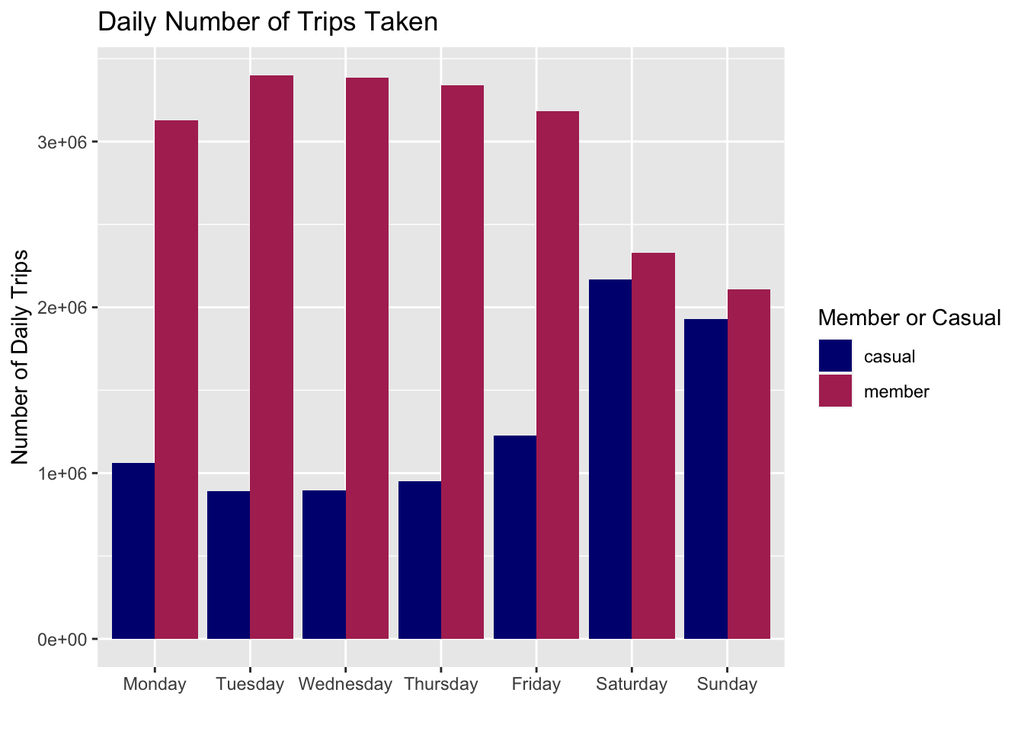

#### Monthly

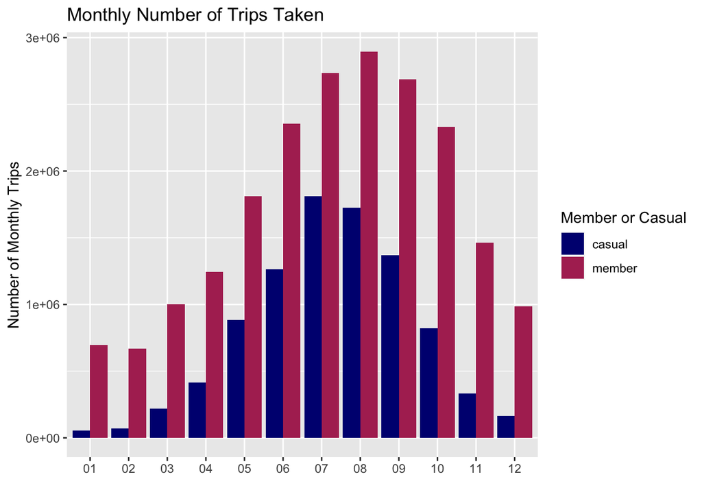

#### Yearly

More than half of the customers of Cyclistic are members. The only exception is the Covid-19 period but the number of members is still higher than casual riders.

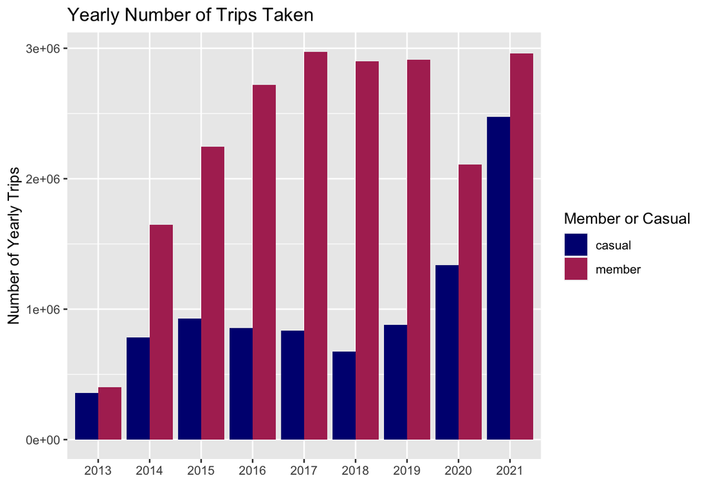

### Analysis on trip duration

#### Daily

Members are using the bikes with a similar frequency during the week. Casual riders are preferring the weekends. In total, weekends are the most used time of the week.

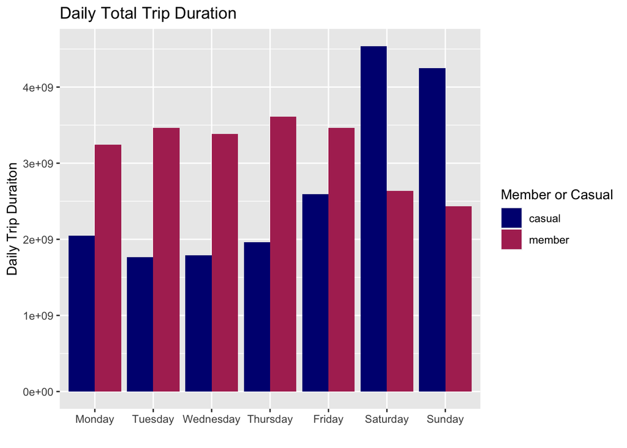

#### Monthly

Summer has the highest demand for bikes for both customer groups. Casual riders have a special interest during the summer.

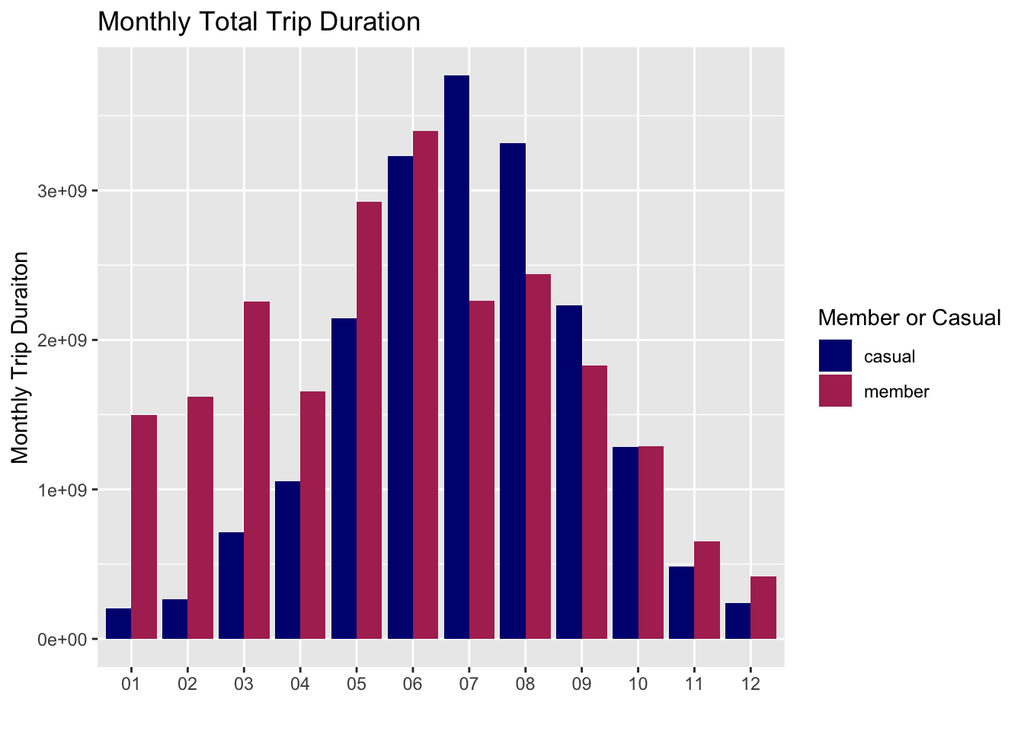

#### Yearly

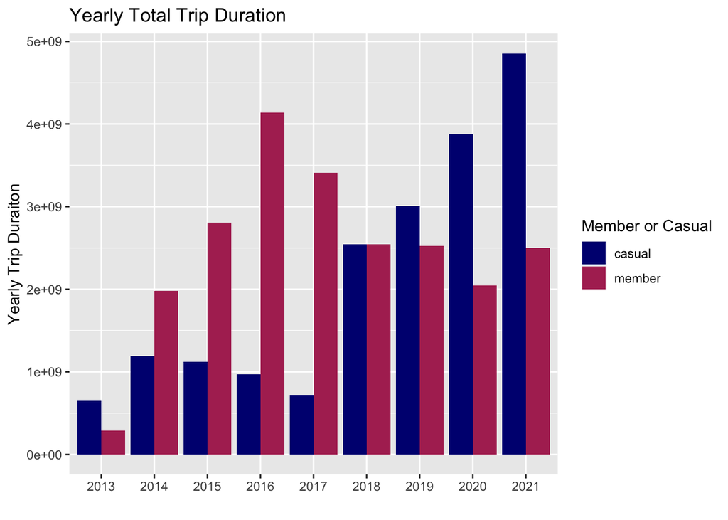

### Recommendations

1. Casual riders have a higher average trip duration, therefore, increasing the number of casual riders will have a more significant marginal effect than the members. Preparing special campaigns targeting casual riders will be more profitable for the company.
2. Summer has the highest demand, prepare campaigns for summer focusing on both customer groups in order to increase the number of total users instead of only focusing on the number of members. Because this attempt may cause a decrease in the number of casual riders which has a higher marginal effect on the revenue.
3. Prepare campaigns for weekends since the demand is at the top on weekends.

### Food for tought

Data includes observations about station locations of each trip. It is possible to run further analysis on the density of the stations in order to replace advertisement tools and balance the number of bikes docked at each station. Moreover, it is possible to manage the bike distribution among stations seasonally since there are data available.